# Power Analysis

## Types of errors and statistical power

|  | Reject H<sub>0</sub> | Fail to reject H<sub>0</sub> |
| --- | --- | --- |
| H<sub>0</sub> is true | Type I error | *Correct* |
| H<sub>0</sub> is false | *Correct* | Type II error |

Type I error occurs when:

- *P* is small by *random chance*, given that \(\alpha\) is chosen ahead of the test

Type II error probability depends on:

- The value of \(\alpha\)
- How “wrong” H<sub>0</sub> is

## Power

- Given a true effect, the probability that a random sample will lead to a rejection of H<sub>0</sub>
  - The proportion of times you **DO NOT** make a Type II error
- Dependent on how different the truth is from the null hypothesis
- Inversely related to type II errors
  - High power \(\rightarrow\) low type II errors
  - Low power \(\rightarrow\) high type II errors

## Power depends on effect size

*Effect size*: The magnitude of the deviation from H<sub>0</sub>.

If we can estimate effect size *before we do the study*, we can estimate the power.

- Use previous information
  - Your own pilot studies
  - Other similar studies
- Determine how big a difference we *wan*t to be able to detect
  - How small of a difference is not biologically meaningful?

## Effect size

> “An effect size is a standardized measure that quantifies the size of the difference between two groups or the strength of an association between two variables.” (Button et al. 2013)

Measures of effect size:

1. Pearson’s *r*
2. *R*<sup>2</sup>: but note caveats of *R*<sup>2</sup>
3. Cohen’s *d*: *t*-tests (Cohen 1960)
4. Cohen’s \(f^2\), \(\eta^2\): ANOVA-like (Olejnik and Algina 2003)
5. Odds ratio (logistic regression)

## Importance of effect size

> “For example, if a sample size is 10 000, a significant *P* value is likely to be found even when the difference in outcomes between groups is negligible and may not justify an expensive or time-consuming intervention over another.” (Sullivan and Feinn 2012)

Consider an ordinary *t*-test:

\[t=\frac{\bar{Y}_{1}-\bar{Y}_{2}}{SE_{Y_{1}-Y_{2}}}\]

## Example calculation of effect size

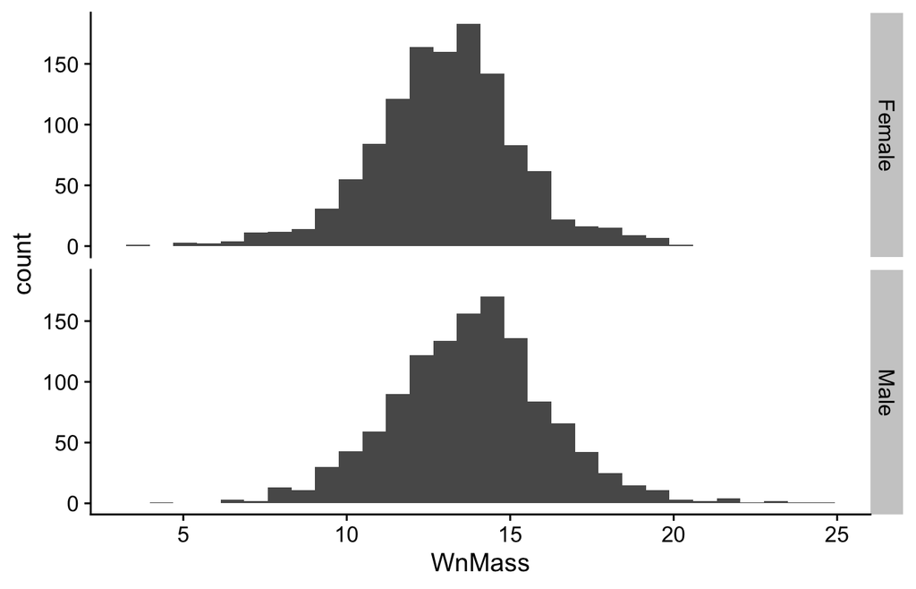

## Cohen’s *d*

Standardized differences measured in standard deviations.

General guide for *t*-tests (also see Sullivan and Feinn 2012):

- 0.2 = “Small”
- 0.5 = “Medium”
- 0.8 = “Large”

What you do with “small,” “medium,” and “large” is up to you.

## According to Cohen

> “there is a certain risk inherent in offering conventional operational definitions for those terms for use in power analysis in as diverse a field of inquiry as behavioral science”

## Cohen’s *d* using the `DescTools` package

\[ d = \frac{\bar{Y_F} - \bar{Y_M}}{s_{\mbox{pooled}}} \]

```r
library(DescTools)
Females <- M %>% filter(Sex == "Female") %>% pull(WnMass)
Males <- M %>% filter(Sex == "Male") %>% pull(WnMass)
CohenD(Females, Males)
```

```
## [1] -0.3417314
## attr(,"magnitude")
## [1] "small"
```

## \(\eta^2\) for jet lag data with `EtaSq()`

Also in `DescTools`:

```r
JL <- read_csv("../data/JetLag.csv", col_types = "cd") %>%
  mutate(Treatment = factor(Treatment))
fm <- lm(Shift ~ Treatment, data = JL)
EtaSq(fm)
```

```
##              eta.sq eta.sq.part
## Treatment 0.4341684   0.4341684
```

## Power analysis is used for planning

1. What sample size do I need for some level of power?
2. What is my power for some sample size?
3. How large of a difference can I detect for some power and sample size?

How much power is enough power? Some say 0.8.

## Post-analysis power calculations

Hoenig and Heisey (2001):

> “There is a large literature advocating that power calculation be made whenever one performs a statistical test of a hypothesis and one obtains a statistically nonsignificant result. … This approach, which appears in various forms, is fundamentally flawed.”
- “Observed power” (power of an observed *P* value from a post-hoc power analysis) is mathematically tied to the *P* value.

## Power analysis in R

1. `pwr` package
   - `pwr.t.test()`
   - `pwr.anova.test()`
   - `pwr.r.test()`
2. Do it yourself. For all but the simplest experimental designs, this is the only option.
   - Simulate data across a range of sample sizes and effect sizes.

## Commonalities

1. *n* samples (*k* groups)
2. *d* or *f* for hypothesized effect size (*r* hypothesized correlation)
3. \(\alpha\) level
4. Power

```r
library(pwr)
cohen.ES(test = "anov", size = "medium")
```

```
##
##      Conventional effect size from Cohen (1982)
##
##            test = anov
##            size = medium
##     effect.size = 0.25
```

## Power analysis for a *t*-test

Possible questions:

1. What sample size do I need for a given effect size, \(\alpha\), and power?
2. What will my power be, for a given effect size, \(\alpha\), and sample?
3. What effect size will I be able to detect for a given sample, power, and \(\alpha\)? (This is difficult, because how do you know power?)

## What sample size?

```r
pwr.t.test(d = 0.5, sig.level = 0.05, power = 0.80,
           type = "two.sample")
```

```
##
##      Two-sample t test power calculation
##
##               n = 63.76561
##               d = 0.5
##       sig.level = 0.05
##           power = 0.8
##     alternative = two.sided
##
## NOTE: n is number in *each* group
```

## What is my power?

```r
pwr.t.test(d = 0.5, sig.level = 0.05, n = 15,
           type = "two.sample")
```

```
##
##      Two-sample t test power calculation
##
##               n = 15
##               d = 0.5
##       sig.level = 0.05
##           power = 0.262443
##     alternative = two.sided
##
## NOTE: n is number in *each* group
```

## What effect size can I detect?

```r
pwr.t.test(power = 0.80, sig.level = 0.05, n = 1227,
           type = "two.sample")
```

```
##
##      Two-sample t test power calculation
##
##               n = 1227
##               d = 0.113158
##       sig.level = 0.05
##           power = 0.8
##     alternative = two.sided
##
## NOTE: n is number in *each* group
```

## Power analysis via simulation

```r
library(pwr)
pwr.t.test(power = 0.8, d = 0.6)
```

```
##
##      Two-sample t test power calculation
##
##               n = 44.58577
##               d = 0.6
##       sig.level = 0.05
##           power = 0.8
##     alternative = two.sided
##
## NOTE: n is number in *each* group
```

## Power analysis via simulation

Estimate power across a range of *d* and *n*:

`d <- seq(0.1, 2, length.out = 50)`

- Standardized mean differences from 0.1 to 2

`n <- c(5, 10, 15, 20, 30, 50, 100)`

- Sample sizes from 5 to 100

## Power analysis via simulation

```r
d_seq <- seq(0.1, 2, length.out = 50)
ns <- c(5, 10, 15, 20, 30, 50, 100)

# All combinations on d_seq and ns
power_t <- crossing(d_seq, ns)
names(power_t) <- c("d", "n")

# Column for calculated power
power_t$power <- numeric(nrow(power_t))

for (i in 1:nrow(power_t)) {
  d <- power_t$d[i]
  n <- power_t$n[i]
  power_t$power[i] <- pwr.t.test(n, d)$power
}
```

## Power analysis via simulation

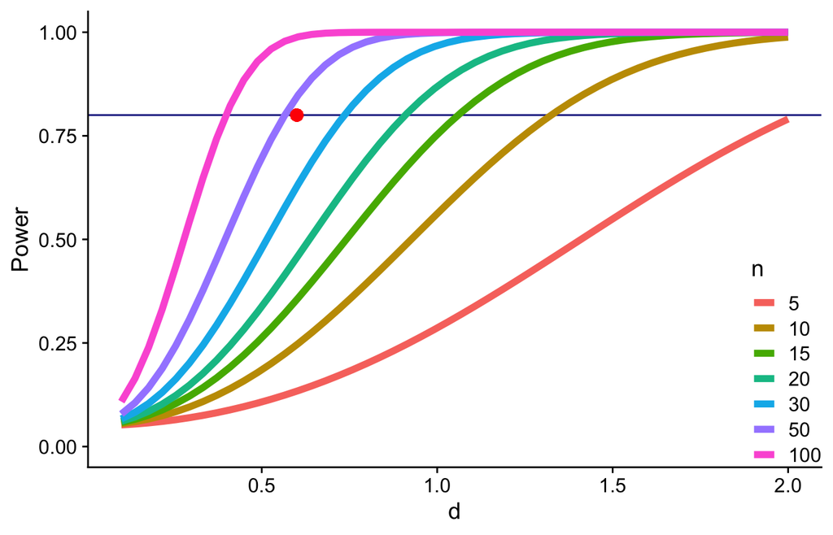

## Power analysis via simulation

Generalizing to any type of analysis:

1. Specify parameters (e.g., *n*, *d*, means, slope, intercept) in a biologically realistic range (reasonable variances)
2. Simulate data that your process produces
3. Determine if *P* value is less than \(\alpha\).
4. Repeat

## Power analysis via simulation

```r
set.seed(20)

nsims <- 1e4
d <- 0.4
n <- 15
alpha <- 0.05
sig <- logical(nsims)  # Vector of TRUE/FALSE

for (i in 1:nsims) {
  x1 <- rnorm(n, mean = 0, sd = 1)
  x2 <- rnorm(n, mean = d, sd = 1)
  p <- t.test(x1, x2, var.equal = TRUE)$p.value
  sig[i] <- p < alpha
}
```

## Power analysis via simulation

```r
head(sig)
```

```
## [1] FALSE  TRUE FALSE FALSE FALSE FALSE
```

```r
mean(sig)
```

```
## [1] 0.1837
```

```r
pwr.t.test(n = 15, d = 0.4)$power
```

```
## [1] 0.1848496
```

## Power analysis via simulation

Simulate data from a exponential process:

\[\mbox{Femur Length} = a \mbox{Mass}^b\]

\[\log \mbox{Femur Length} = \log a + b \log \mbox{Mass}\]

What is the power to detect deviations from isometry?

- Simulate across a range of *n*
- Use a range of slopes from 1/3 - 0.2 to 1/3 + 0.2

## Power analysis via simulation

```r
nsims <- 1e4
alpha <- 0.05
ns <- c(5, 10, 25, 50, 100, 200, 400)
b_null <- 1/3
b_devs <- seq(-0.2, 0.2, length.out = 100)

# All combinations of ns and b_devs
pwr_reg <- crossing(ns, b_devs)
names(pwr_reg) <- c("n", "b_dev")
pwr_reg$Power <- NA
```

## Power analysis via simulation

```r
set.seed(912)
# Iterate through the rows of `pwr_reg`
for (i in 1:nrow(pwr_reg)) {
  tic <- Sys.time()
  message(i, " of ", nrow(pwr_reg))
  n <- pwr_reg$n[i]
  b_dev <- pwr_reg$b_dev[i]
  sig <- logical(nsims)

  for (j in 1:nsims) {
    log_Mass <- log(runif(n, 1, 1e3))
    log_a <- rnorm(n, 1.31, 0.15)
    log_Fem_Len <- log_a + (b_null + b_dev) * log_Mass
    fm <- sma(log_Fem_Len ~ log_Mass, slope.test = b_null, method = "OLS")
    sig[j] <- fm$slopetest[[1]]$p < alpha
  }
  pwr_reg$Power[i] <- mean(sig)
  save(pwr_reg, file = "./data/pwr_reg_SMA.Rda")
  message(Sys.time() - tic)
}
```

- Mass uniformly distributed from 1 - 1000
- \(a\) normally distributed with a mean of 1.31
- Calculate `log_Fem_Len`

## Power analysis via simulation

- 7,000,000 regressions
- ~8 hours later…

## Power analysis via simulation

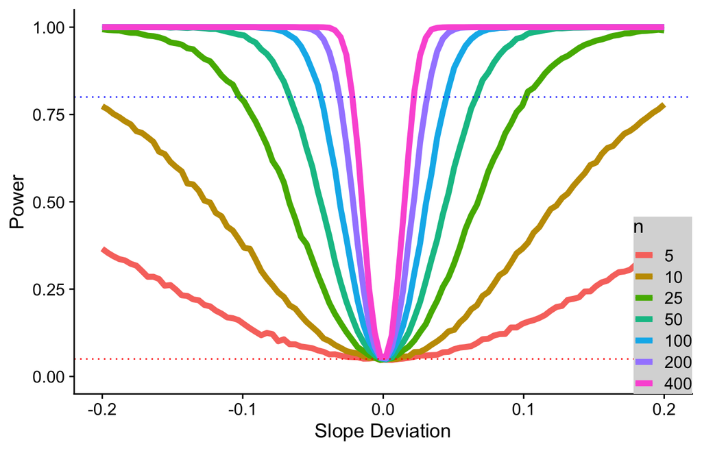

## Power in multi-parent genetic mapping populations (MPPs)

[figure not shown]

## Power in MPPs

```r
eff <- 0.05
envs <- rnorm(length(genos),0,sqrt(((1/eff)-1)*var(genos)))
phenos <- genos + envs

print(cbind(genos, phenos))
```

```
##       genos       phenos
##  [1,]     0 -1.539135715
##  [2,]     0  0.141271494
##  [3,]     1 -0.341832402
##  [4,]     1 -3.555101401
##  [5,]     0 -4.616669962
##  [6,]     0  0.008531178
##  [7,]     1  2.122645226
##  [8,]     0  2.280615711
##  [9,]     1  2.324311402
## [10,]     1  2.786139988
```

```r
print(c(mean(phenos[genos==0]),mean(phenos[genos==1])))
```

```
## [1] -0.7450775  0.6672326
```

## Power in MPPs

[figure not shown]

## Power in MPPs

[figure not shown]

## References

Button, K. S., J. P. A. Ioannidis, C. Mokrysz, B. A. Nosek, J. Flint, E. S. J. Robinson, and M. R. Munafò. 2013. Power Failure: Why Small Sample Size Undermines the Reliability of Neuroscience. *Nat. Rev. Neurosci.* 14:365–376.

Cohen, J. 1960. A Coefficient of Agreement for Nominal Scales. *Educ. Psychol. Meas.* 20:37–46.

Hoenig, J. M., and D. M. Heisey. 2001. The Abuse of Power: The Pervasive Fallacy of Power Calculations for Data Analysis. *Am. Stat.* 55:19–24. [American Statistical Association, Taylor & Francis, Ltd.].

Olejnik, S., and J. Algina. 2003. Generalized Eta and Omega Squared Statistics: Measures of Effect Size for Some Common Research Designs. *Psychol. Methods* 8:434–447.

Sullivan, G. M., and R. Feinn. 2012. Using Effect Size—or Why the *p* Value Is Not Enough. *J. Grad. Med. Educ.* 4:279–282.